# R Notebook

```r
library(readr)
library(ggplot2)
library(dplyr)
library(corrplot)
library(corrplot)
library(caret)
```

## Introduccion

El presente notebook se centra en el análisis y modelado de datos de un supermercado, con el objetivo de comprender mejor el comportamiento de los clientes y explorar la posibilidad de predecir el gasto total en función de variables específicas. A través de visualizaciones y técnicas de regresión lineal, se busca identificar patrones de compra, factores influyentes y evaluar la capacidad predictiva del modelo.

## Objetivos

Hacer una exploracion descriptiva y Utilizar un modelo de regresión lineal para predecir el gasto total basado en la cantidad y precio unitario de los productos adquiridos.

Estos objetivos combinados proporcionarán una comprensión integral del panorama de clientes del supermercado, permitiendo la identificación de patrones de comportamiento y la evaluación de la eficacia de un modelo de regresión lineal en la predicción del gasto total.

```r
df <- read_csv('supermarket_db.csv', show_col_types = FALSE)
#head(df)
summary(df)
```

```
##   Invoice ID           Branch              City           Customer type
##  Length:1000        Length:1000        Length:1000        Length:1000
##  Class :character   Class :character   Class :character   Class :character
##  Mode  :character   Mode  :character   Mode  :character   Mode  :character
##
##
##
##     Gender          Product line         Unit price       Quantity
##  Length:1000        Length:1000        Min.   :10.08   Min.   : 1.00
##  Class :character   Class :character   1st Qu.:32.88   1st Qu.: 3.00
##  Mode  :character   Mode  :character   Median :55.23   Median : 5.00
##                                        Mean   :55.67   Mean   : 5.51
##                                        3rd Qu.:77.94   3rd Qu.: 8.00
##                                        Max.   :99.96   Max.   :10.00
##      Tax 5%            Total             Date               Time
##  Min.   : 0.5085   Min.   :  10.68   Length:1000        Length:1000
##  1st Qu.: 5.9249   1st Qu.: 124.42   Class :character   Class1:hms
##  Median :12.0880   Median : 253.85   Mode  :character   Class2:difftime
##  Mean   :15.3794   Mean   : 322.97                      Mode  :numeric
##  3rd Qu.:22.4453   3rd Qu.: 471.35
##  Max.   :49.6500   Max.   :1042.65
##    Payment               cogs        gross margin percentage  gross income
##  Length:1000        Min.   : 10.17   Min.   :4.762           Min.   : 0.5085
##  Class :character   1st Qu.:118.50   1st Qu.:4.762           1st Qu.: 5.9249
##  Mode  :character   Median :241.76   Median :4.762           Median :12.0880
##                     Mean   :307.59   Mean   :4.762           Mean   :15.3794
##                     3rd Qu.:448.90   3rd Qu.:4.762           3rd Qu.:22.4453
##                     Max.   :993.00   Max.   :4.762           Max.   :49.6500
##      Rating
##  Min.   : 4.000
##  1st Qu.: 5.500
##  Median : 7.000
##  Mean   : 6.973
##  3rd Qu.: 8.500
##  Max.   :10.000
```

Buscando valores nulos en el dataset:

```r
missing_values <- colSums(is.na(df))
print(missing_values)
```

```
##              Invoice ID                  Branch                    City
##                       0                       0                       0
##           Customer type                  Gender            Product line
##                       0                       0                       0
##              Unit price                Quantity                  Tax 5%
##                       0                       0                       0
##                   Total                    Date                    Time
##                       0                       0                       0
##                 Payment                    cogs gross margin percentage
##                       0                       0                       0
##            gross income                  Rating
##                       0                       0
```

Análisis visual de las muestras dividida en género (Male or Female)

```r
gender_counts <- table(df$Gender)
print(gender_counts)
```

```
##
## Female   Male
##    501    499
```

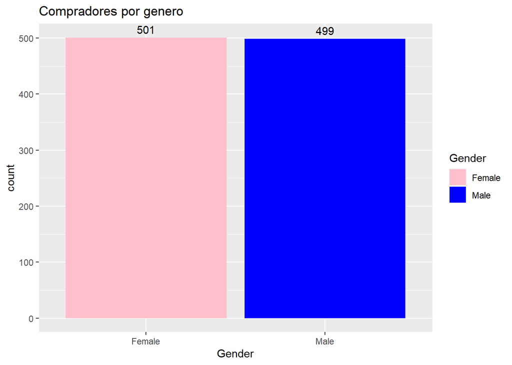

```r
ggplot(df, aes(x = Gender, fill = Gender)) +
  geom_bar() +
  geom_text(stat = 'count', aes(label = after_stat(count)), vjust = -0.5) +
  scale_fill_manual(values = c("Male" = "blue", "Female" = "pink")) +
  labs(title = "Compradores por genero")
```

Prácticamente no se encuentra diferencia alguna en cuanto a asistencia al mercado entre hombres y mujeres, siendo las mujeres las que más asisten con un total de 501 muestras y hombres 499.

[output not shown]

Vizualización de los métodos de pago més utilizados por los clientes.

```r
payment_df <- df %>%
  group_by(Payment) %>%
  summarise(Count = n())
print(payment_df)
```

```
## # A tibble: 3 × 2
##   Payment     Count
##   <chr>       <int>
## 1 Cash          344
## 2 Credit card   311
## 3 Ewallet       345
```

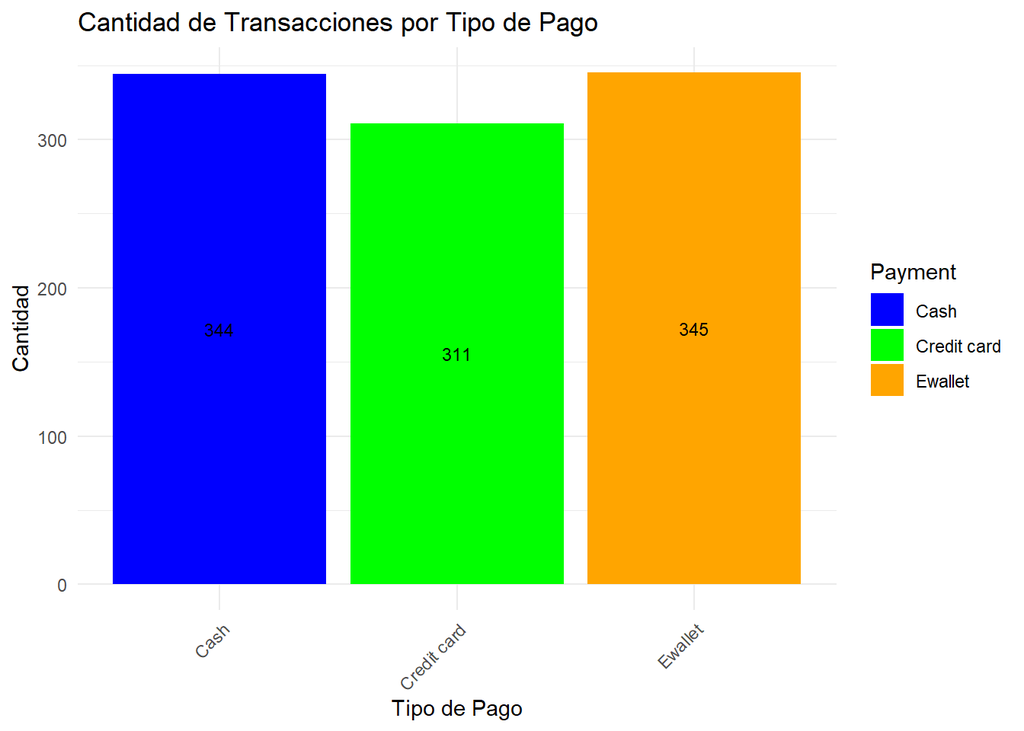

```r
ggplot(payment_df, aes(x = Payment, y = Count, fill = Payment, label = Count)) +
  geom_bar(stat = "identity") +
  geom_text(position = position_stack(vjust = 0.5), size = 3) +
  labs(title = "Cantidad de Transacciones por Tipo de Pago", x = "Tipo de Pago", y = "Cantidad") +
  theme_minimal() +
  theme(axis.text.x = element_text(angle = 45, hjust = 1)) +
  scale_fill_manual(values = c("Cash" = "blue", "Credit card" = "green", "Ewallet" = "orange"))
```

Visualización de líneas de producto que tienen más ingresos brutos.

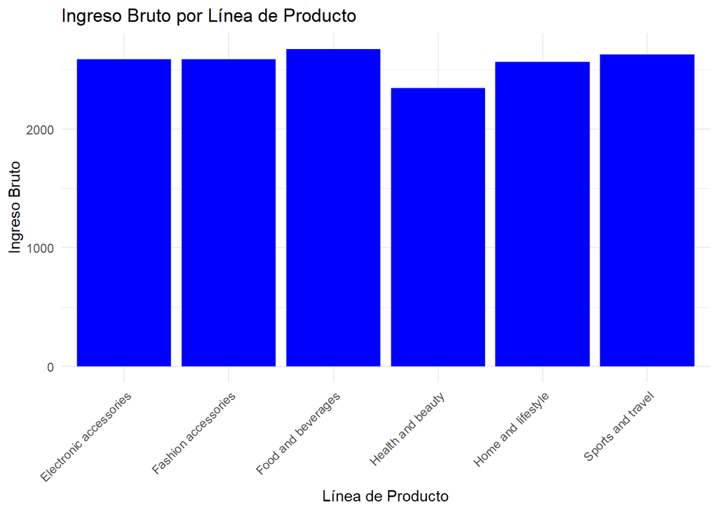

```r
ggplot(df, aes(x = `Product line`, y = `gross income`)) +
  geom_bar(stat = "identity", fill = "blue") +
  labs(title = "Ingreso Bruto por Línea de Producto", x = "Línea de Producto", y = "Ingreso Bruto") +
  theme_minimal() +
  theme(axis.text.x = element_text(angle = 45, hjust = 1))
```

Visualización de la calificación para cada línea de producto.

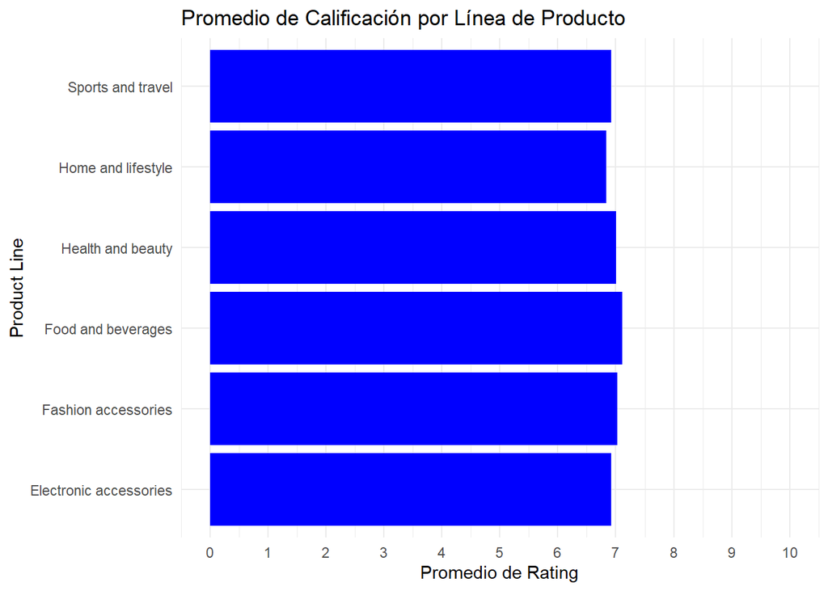

```r
df %>%
  group_by(`Product line`) %>%
  summarise(Avg_Rating = mean(Rating, na.rm = TRUE)) %>%
  ggplot(aes(x = Avg_Rating, y = `Product line`)) +
  geom_col(fill = "blue") +
  labs(title = "Promedio de Calificación por Línea de Producto", x = "Promedio de Rating", y = "Product Line") +
  theme_minimal() +
  scale_x_continuous(limits = c(0, 10), breaks = seq(0, 10, by = 1))
```

Utilizaremos el modelo de regresión lineal para predecir el total que se gastara un cliente en cada compra.

```r
data_total <- df[, c('Customer type', 'Quantity', 'Unit price', 'Total')]
set.seed(123)
indices_entrenamiento <- sample(1:nrow(data_total), 0.9 * nrow(data_total))
df_entrenamiento <- data_total[indices_entrenamiento, ]
df_prueba <- data_total[-indices_entrenamiento, ]
```

Entrenando el modelo

```r
modelo_regresion <- lm(Total ~ Quantity + `Unit price`, data = df_entrenamiento)
summary(modelo_regresion)
```

```
##
## Call:
## lm(formula = Total ~ Quantity + `Unit price`, data = df_entrenamiento)
##
## Residuals:
##      Min       1Q   Median       3Q      Max
## -212.609  -47.128    1.733   46.131  217.259
##
## Coefficients:
##               Estimate Std. Error t value Pr(>|t|)
## (Intercept)  -324.1002     8.1084  -39.97   <2e-16 ***
## Quantity       58.8570     0.9280   63.42   <2e-16 ***
## `Unit price`    5.7682     0.1016   56.77   <2e-16 ***
## ---
## Signif. codes:  0 '***' 0.001 '**' 0.01 '*' 0.05 '.' 0.1 ' ' 1
##
## Residual standard error: 80.91 on 897 degrees of freedom
## Multiple R-squared:  0.8889, Adjusted R-squared:  0.8887
## F-statistic:  3589 on 2 and 897 DF,  p-value: < 2.2e-16
```

```r
print(sqrt(0.8895))
```

```
## [1] 0.9431331
```

La variable R cuadrado nos dice que tanto explica las variables dependientes las ventas

```r
predicciones <- predict(modelo_regresion, newdata = df_prueba)
df_prueba$Predicciones <- predicciones
```

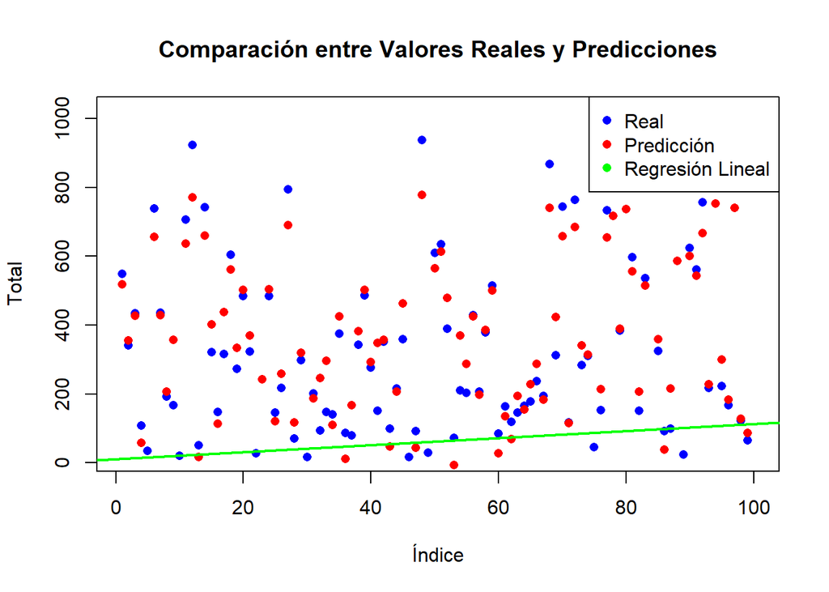

```r
plot(df_prueba$Total, col = "blue", pch = 16, xlab = "Índice", ylab = "Total", main = "Comparación entre Valores Reales y Predicciones")
points(df_prueba$Predicciones, col = "red", pch = 16)

abline(lm(Total ~ Predicciones, data = df_prueba), col = "green", lwd = 2)
legend("topright", legend = c("Real", "Predicción", "Regresión Lineal"), col = c("blue", "red", "green"), pch = 16)
```

```r
mse <- mean((df_prueba$Total - df_prueba$Predicciones)^2)
print(mse)
```

```
## [1] 7683.717
```

```r
mae <- mean(abs(df_prueba$Total - df_prueba$Predicciones))
print(mae)
```

```
## [1] 67.41683
```

```r
rsquared <- 1 - sum((df_prueba$Total - df_prueba$Predicciones)^2) / sum((df_prueba$Total - mean(df_prueba$Total))^2)
print(rsquared)
```

```
## [1] 0.8969456
```

```r
head(df_prueba)
```

| Customer type | Quantity | Unit price | Total | Predicciones |
| --- | --- | --- | --- | --- |
| Member | 7 | 74.69 | 548.9715 | 518.72704 |
| Normal | 7 | 46.33 | 340.5255 | 355.14033 |
| Member | 6 | 68.84 | 433.6920 | 426.12597 |
| Member | 4 | 25.51 | 107.1420 | 58.47505 |
| Normal | 1 | 33.52 | 35.1960 | -71.89246 |
| Member | 9 | 78.07 | 737.7615 | 655.93758 |